# Prediction and Machine Learning Course Project

atops

August 16, 2015

This project uses data from accelerometers on the belt, forearm, arm, and dumbbell of 6 participants who were asked to perform barbell lifts correctly and incorrectly in 5 different ways. The goal of this project is to predict the manner in which they did the exercise.

The following is a report describing (a) how I built the model, (b) how I used cross validation, (c) what I think the expected out of sample error is, and (d) why I made the choices I did.

## A. Building the model

I started by inspecting the data in Excel. It was clear from the outset that several of the variables had many missing values. Of the 160 columns, there were 60 feature complete columns (19622 observations) and 100 columns with only 406 observations. Given this, as a starting point I decided to start with the 60 feature complete factors and discard the others. A more rigorous analysis would have explored the other factors as well, for the observations where they were largely complete, with some imputation for further missing values (of which there were some).

Subtracting out the non-qualitative factors such as `timestamps`, `window` and `user_name` resulted in 51 factors to consider. In order for this training data to be generalizable to other users beyond the 6 used for training (which is the whole point of the exercise), I left out `user_name` as a factor even though exploratory plots indicated it would have good predictive power.

Initially, I decided to create a naive model that used all of the 51 variables I had left. Using methods such as partial least squares (`method="pls"`) and recursive partitioning (`method="rpart"`) I was able to get a model to run in a reasonable amount of time. However, the confusion matrix showed a lot of error. The predictions were really bad. The model I wanted to run, random forests (`method="rf"`) didn’t complete after a very long time before I terminated the session.

The partial least squares model I ran initially on all the input factors yielded the following results:

```r
tc0 <- trainControl(method="repeatedcv",
                   number=10,
                   repeats=3,
                   classProbs=TRUE,
                   allowParallel=TRUE)
trfit0 <- train(classe ~.,
               data=select(trdf,-user_name),
               trControl=tc0,
               method="pls")
cm <- confusionMatrix(trfit0)
cm
```

```
## Cross-Validated (10 fold, repeated 3 times) Confusion Matrix
##
## (entries are percentages of table totals)
##
##           Reference
## Prediction    A    B    C    D    E
##          A 21.2  7.7 11.0  5.0  7.2
##          B  1.8  7.8  2.4  2.5  5.5
##          C  0.4  0.2  0.5  0.6  0.6
##          D  4.5  3.0  3.2  7.3  4.1
##          E  0.6  0.7  0.3  0.9  1.0
```

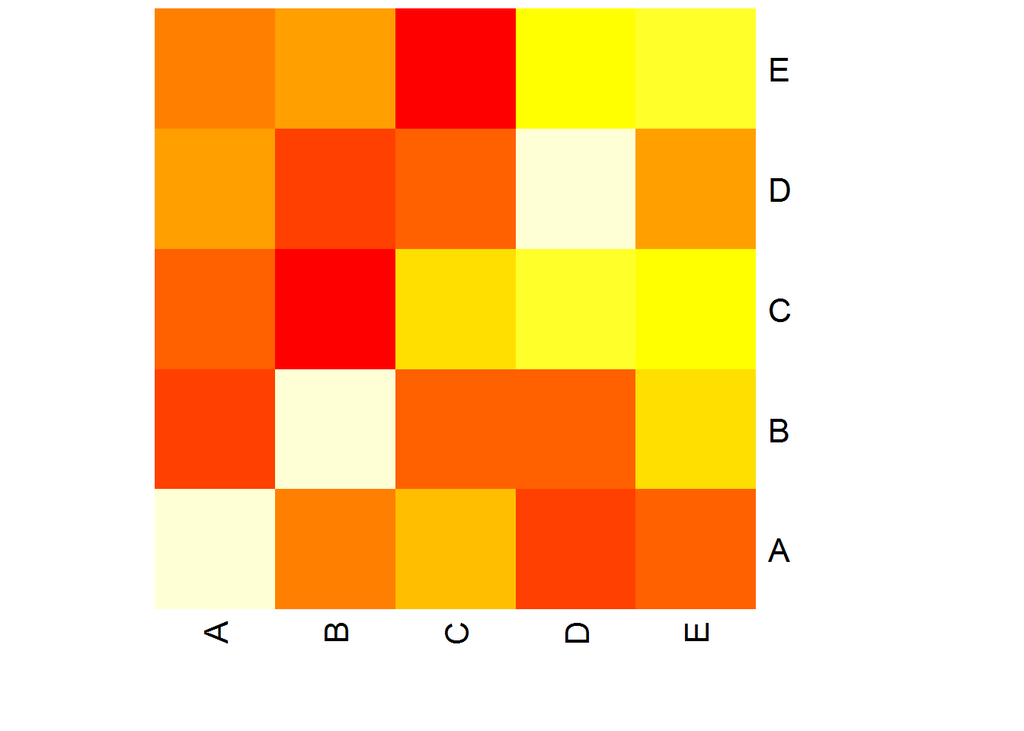

```r
heatmap(cm$table, Rowv=NA, Colv=NA)
```

Trying to be a little smarter about covariate selection, I made several exploratory plots, including box plots of each of the factors against the `classe` variable. Some of these are shown in the Appendix. These showed several outliers which were contained within only 3 observations. I threw those 3 observations out.

```r
# Remove outliers
trdf %<>% filter(accel_belt_x > -100 &
                         gyros_dumbbell_x > -200 &
                         gyros_forearm_x > -20 &
                         gyros_dumbbell_y < 40 &
                         magnet_dumbbell_y > -1000 &
                         gyros_forearm_y < 300 &
                         accel_forearm_y < 750 &
                         gyros_dumbbell_z < 300 &
                         gyros_forearm_z < 200 &
                         total_accel_dumbbell < 50 &
                         total_accel_forearm < 90)
```

I then visually looked for a few variables that showed the highest relationship with classe from the box plots. I also used the `varImp` function from `caret` to identify which factors carried the most importance on the initial model.

```r
vi <- varImp(trfit0$finalModel)*10000000
vi$Sum <- rowSums(vi)
kable(vi[order(-vi$Sum),], align = "r", digits=2)
```

|  | A | B | C | D | E | Sum |
| --- | --- | --- | --- | --- | --- | --- |
| magnet_arm_x | 1641.76 | 1284.14 | 587.06 | 714.73 | 727.54 | 4955.22 |
| magnet_arm_z | 881.85 | 1856.01 | 755.28 | 528.12 | 406.90 | 4428.16 |
| magnet_dumbbell_x | 514.71 | 2184.01 | 766.29 | 344.40 | 269.31 | 4078.72 |
| magnet_forearm_x | 896.88 | 626.62 | 449.53 | 556.07 | 367.36 | 2896.46 |
| magnet_dumbbell_y | 168.32 | 1569.65 | 576.10 | 221.53 | 99.37 | 2634.96 |
| magnet_forearm_y | 940.92 | 284.87 | 256.81 | 454.62 | 393.99 | 2331.22 |
| accel_arm_x | 565.55 | 498.69 | 206.86 | 234.68 | 254.47 | 1760.24 |
| accel_forearm_x | 505.19 | 229.64 | 172.72 | 260.15 | 211.50 | 1379.20 |
| magnet_arm_y | 628.05 | 127.32 | 70.09 | 209.27 | 276.47 | 1311.19 |
| accel_dumbbell_x | 177.92 | 630.06 | 216.41 | 102.09 | 91.62 | 1218.11 |
| accel_dumbbell_z | 161.16 | 530.18 | 192.97 | 101.09 | 80.17 | 1065.57 |
| accel_dumbbell_y | 54.62 | 648.12 | 231.63 | 80.52 | 35.58 | 1050.47 |
| magnet_dumbbell_z | 245.67 | 195.06 | 132.71 | 156.04 | 100.81 | 830.28 |
| roll_dumbbell | 100.22 | 436.23 | 155.52 | 70.84 | 52.19 | 815.00 |
| accel_arm_z | 45.01 | 394.83 | 203.23 | 121.37 | 15.40 | 779.83 |
| accel_forearm_y | 170.83 | 161.77 | 138.78 | 152.53 | 63.68 | 687.59 |
| yaw_dumbbell | 50.30 | 375.34 | 155.75 | 75.71 | 24.90 | 682.00 |
| magnet_forearm_z | 251.46 | 94.58 | 87.10 | 136.59 | 103.42 | 673.15 |
| pitch_dumbbell | 89.19 | 343.45 | 122.16 | 58.22 | 45.71 | 658.73 |
| accel_belt_z | 76.61 | 246.93 | 87.03 | 44.33 | 38.55 | 493.45 |
| roll_arm | 121.73 | 167.28 | 78.31 | 70.36 | 53.53 | 491.21 |
| accel_arm_y | 127.29 | 83.95 | 50.01 | 65.05 | 54.27 | 380.57 |
| pitch_forearm | 134.29 | 60.89 | 50.08 | 73.83 | 55.44 | 374.54 |
| yaw_arm | 77.12 | 110.64 | 57.73 | 52.23 | 32.80 | 330.52 |
| magnet_belt_y | 77.94 | 91.02 | 37.57 | 35.83 | 35.25 | 277.61 |
| yaw_forearm | 84.92 | 67.46 | 40.63 | 48.09 | 35.82 | 276.92 |
| magnet_belt_z | 73.29 | 62.09 | 24.44 | 28.53 | 33.20 | 221.55 |
| roll_forearm | 15.39 | 88.52 | 52.69 | 36.58 | 4.49 | 197.67 |
| accel_forearm_z | 39.83 | 71.93 | 29.67 | 22.43 | 18.20 | 182.06 |
| pitch_arm | 63.11 | 19.61 | 9.40 | 21.64 | 27.91 | 141.67 |
| total_accel_dumbbell | 7.59 | 57.94 | 21.86 | 9.21 | 4.17 | 100.77 |
| total_accel_forearm | 20.14 | 36.52 | 16.65 | 13.13 | 8.91 | 95.36 |
| total_accel_arm | 13.91 | 27.84 | 14.09 | 11.19 | 5.90 | 72.92 |
| accel_belt_x | 1.74 | 47.53 | 16.11 | 4.32 | 1.77 | 71.47 |
| accel_belt_y | 7.07 | 34.33 | 12.88 | 6.06 | 3.62 | 63.96 |
| magnet_belt_x | 18.60 | 4.99 | 4.09 | 8.08 | 7.92 | 43.67 |
| total_accel_belt | 4.97 | 12.65 | 4.38 | 2.46 | 2.45 | 26.90 |
| gyros_arm_y | 0.26 | 1.69 | 0.59 | 0.23 | 0.15 | 2.92 |
| gyros_arm_x | 0.10 | 1.65 | 0.71 | 0.33 | 0.05 | 2.84 |
| gyros_forearm_y | 0.38 | 1.04 | 0.51 | 0.37 | 0.16 | 2.47 |
| gyros_forearm_z | 0.09 | 1.17 | 0.45 | 0.18 | 0.05 | 1.95 |
| gyros_dumbbell_x | 0.21 | 0.62 | 0.30 | 0.21 | 0.09 | 1.42 |
| gyros_forearm_x | 0.22 | 0.37 | 0.16 | 0.13 | 0.10 | 0.98 |
| gyros_dumbbell_z | 0.21 | 0.25 | 0.14 | 0.14 | 0.09 | 0.84 |
| gyros_belt_x | 0.02 | 0.25 | 0.09 | 0.03 | 0.01 | 0.40 |
| gyros_dumbbell_y | 0.09 | 0.11 | 0.06 | 0.05 | 0.04 | 0.35 |
| gyros_arm_z | 0.04 | 0.07 | 0.05 | 0.04 | 0.01 | 0.22 |
| gyros_belt_y | 0.01 | 0.09 | 0.04 | 0.02 | 0.01 | 0.17 |
| gyros_belt_z | 0.06 | 0.00 | 0.01 | 0.02 | 0.02 | 0.11 |

I took the x, y and z components of the most significant variables and added these to my model to see if I could a random forest model to complete. It took a while to complete but the results were very good.

The final model as run is as follows.

```r
tc <- trainControl(method="repeatedcv",
                   number=10,
                   repeats=3,
                   classProbs=TRUE,
                   allowParallel=TRUE)
trfit <- train(classe ~ roll_dumbbell + yaw_dumbbell +pitch_dumbbell +
                       magnet_arm_x + magnet_arm_y + magnet_arm_z +
                       magnet_dumbbell_x + magnet_dumbbell_y + magnet_dumbbell_z +
                       magnet_forearm_x + magnet_forearm_y + magnet_forearm_z +
                       magnet_dumbbell_x + magnet_dumbbell_y + magnet_dumbbell_z +
                       accel_arm_x + accel_arm_y + accel_arm_z +
                       accel_forearm_x + accel_forearm_y + accel_forearm_z,
               data=trdf,
               trControl=tc,
               method="rf")
cm <- confusionMatrix(trfit)
cm
```

```
## Cross-Validated (10 fold, repeated 3 times) Confusion Matrix
##
## (entries are percentages of table totals)
##
##           Reference
## Prediction    A    B    C    D    E
##          A 28.3  0.5  0.0  0.1  0.1
##          B  0.0 18.5  0.3  0.0  0.2
##          C  0.0  0.2 17.0  0.5  0.1
##          D  0.1  0.1  0.0 15.6  0.3
##          E  0.0  0.1  0.1  0.2 17.8
```

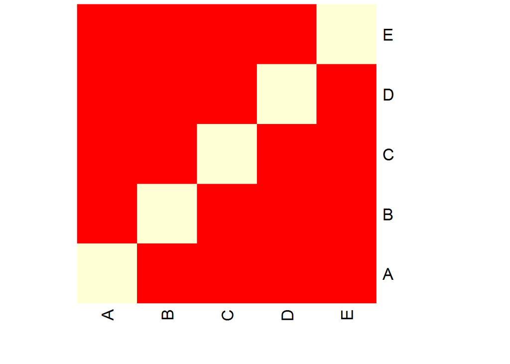

```r
heatmap(cm$table, Rowv=NA, Colv=NA)
```

## B. Cross-Validation

I used K-fold cross validation(`method="repeatedcv"`) with 10 folds (`number=10`) repeated 3 times (`repeats=3`). This divides the training set into 10 folds so each training and testing set is 90% and 10% of the training data, respectively. This was repeated 3 times with different k-fold partitions. Cross-validation reduces model overfitting by effectively creating multiple training and testing sets within the training data to test the model.

## C. Expected Out-of-Sample Error

Out-of-sample error is error from model predictions on a new data set. This is in contrast to in-sample error which is based on the training set.

Training model accuracy (in-sample) is as follows:

```r
cm <- confusionMatrix(trfit)

prd <- predict(trfit, newdata=training)
print(confusionMatrix(prd, reference=training$classe))
```

```
## Confusion Matrix and Statistics
##
##           Reference
## Prediction    A    B    C    D    E
##          A 5579    0    0    0    0
##          B    0 3797    0    0    0
##          C    0    0 3422    0    0
##          D    0    0    0 3216    0
##          E    1    0    0    0 3607
##
## Overall Statistics
##
##                Accuracy : 0.9999
##                  95% CI : (0.9997, 1)
##     No Information Rate : 0.2844
##     P-Value [Acc > NIR] : < 2.2e-16
##
##                   Kappa : 0.9999
##  Mcnemar's Test P-Value : NA
##
## Statistics by Class:
##
##                      Class: A Class: B Class: C Class: D Class: E
## Sensitivity            0.9998   1.0000   1.0000   1.0000   1.0000
## Specificity            1.0000   1.0000   1.0000   1.0000   0.9999
## Pos Pred Value         1.0000   1.0000   1.0000   1.0000   0.9997
## Neg Pred Value         0.9999   1.0000   1.0000   1.0000   1.0000
## Prevalence             0.2844   0.1935   0.1744   0.1639   0.1838
## Detection Rate         0.2843   0.1935   0.1744   0.1639   0.1838
## Detection Prevalence   0.2843   0.1935   0.1744   0.1639   0.1839
## Balanced Accuracy      0.9999   1.0000   1.0000   1.0000   1.0000
```

We expect the out-of-sample error to be greater than the in-sample error.

## D. Explanation of Choices

I chose the random forests method because it was taught in the lectures, is relatively easy to understand conceptually and because it is reported to produce good results. However, it took a long time to run. I chose k-fold cross validation because it was straightforward to understand. I chose the factors to include in the model based on their relative importance based on an initial partial least squares model, and based on visual inspection of their variability compared with classe. I would have gone to more sophisticated lengths had the model not turned out well, or had it not taken so long to run with more variables.

## Appendix

A few of the exploratory plots I created are included here.

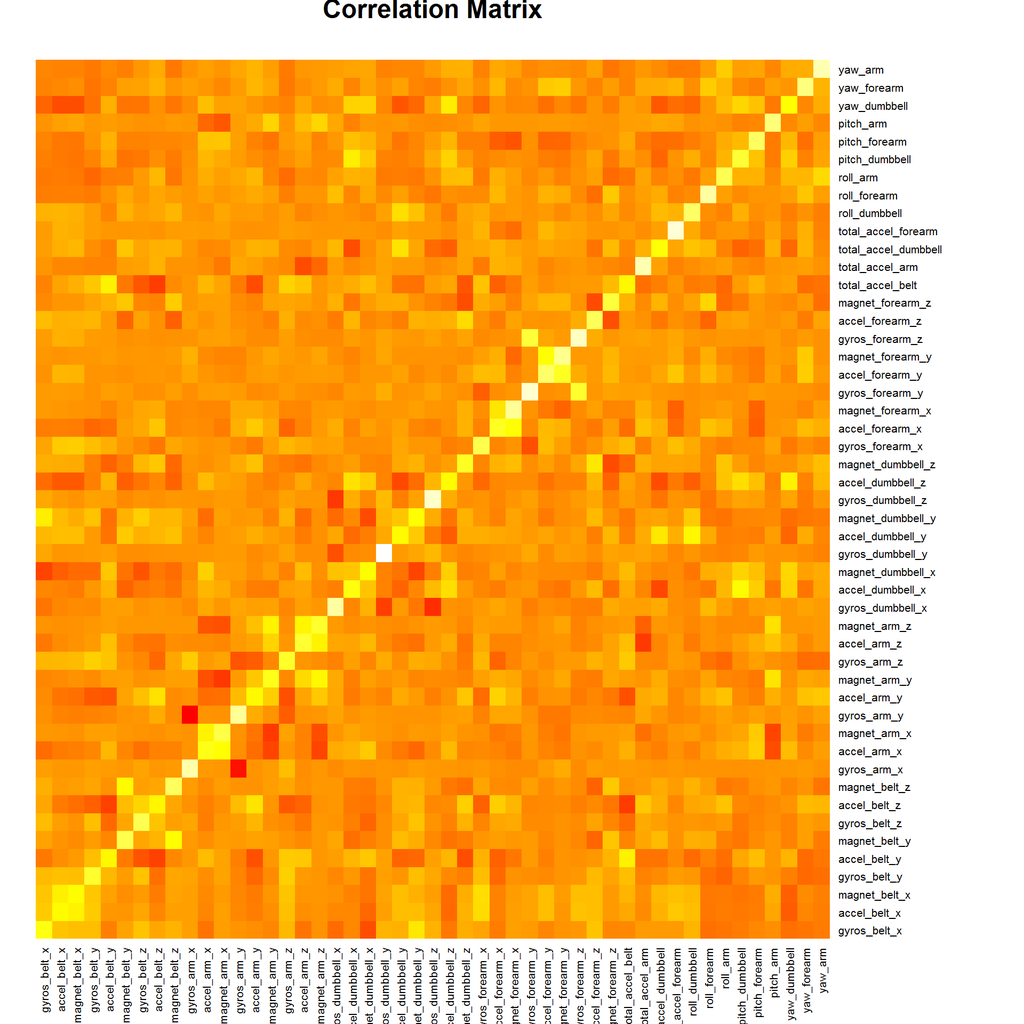

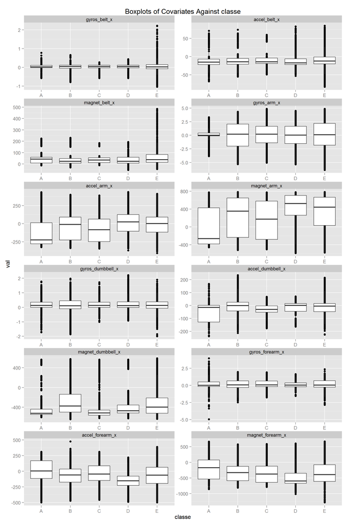

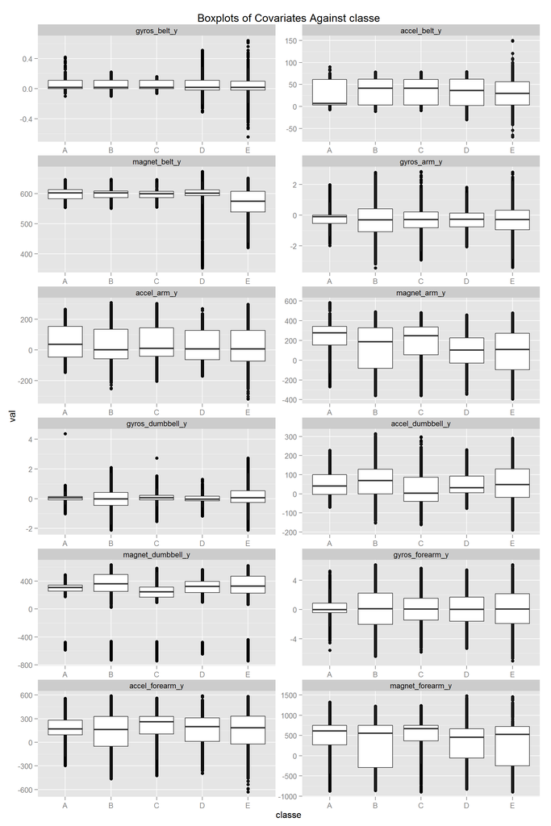

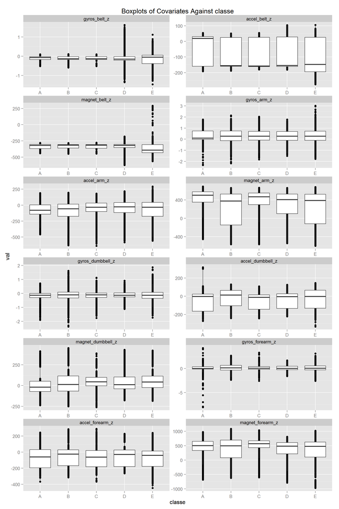

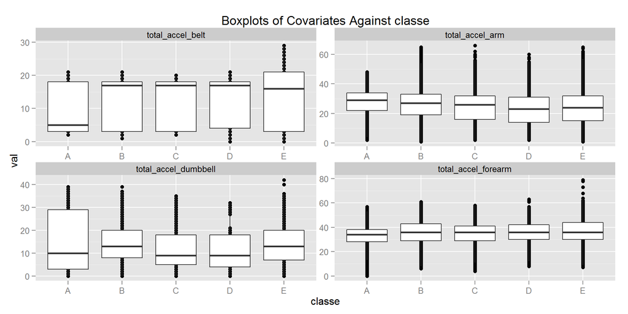